# Large trees

NO_DLTA_001

Authors

Affiliations

Aud Helen Halbritter

University of Bergen

Ulrika Jansson Asplund

Norwegian Institute for Nature Research

Erik Framstad

Norwegian Institute for Nature Research

Mari Jönsson

Norwegian Institute for Nature Research

Oliver Snoksrud

Norwegian Institute of Bioeconomy Research

Ken Olaf Storaunet

Norwegian Institute of Bioeconomy Research

Published

June 9, 2026

Reviewed by

Matthew Grainger

> **Recommended citation**: Halbritter, A. H., Jansson Asplund, U., Framstad, E., Jönsson, M., Snoksrud, O., and Storaunet, K. O. 2026. Large trees (ID(s): NO_DLTA_001) v. 1.0.0. ecRxiv: https://github.com/NINAnor/ecRxiv/tree/main/indicators/NO_DLTA_001

**Metadata**

Table 1: Indicator metadata

[output not shown]

**Log**

- 08 Nov. 2025 - Original PR (NO_LTFA_001)
- 09 Jun. 2026 - NO_DLTA_001: ecTools workflow, national refs X0 = 0%, X100 are county specific
- 18 July 2026 - Accepted

## 1. Summary

1. **Background and rationale**: his indicator represents the proportion of the forest area with presence of trees with a diameter at breast height (DBH) above a tree species and forest productivity-class specific threshold. Tree size threholds range from 17 cm for birch, rowan, grey alder, hazel and a few other less abundant species in unproductive forests to ≥49 cm for pine trees in high productive forest (see Table 2). In intact forest ecosystems where effects of human activities are clearly subordinate to those of natural disturbances and succession, large trees are expected to occur to a higher extent than today. Historical harvesting of large trees and short harvest rotations in current forestry tend to prevent trees from growing very large.
2. **Methods**: Data for this indicator come from the National Forest Inventory (NFI), where the diameter at breast height (dbh) of all trees ≥5 cm dbh within the 250 m² NFI plot has been recorded by current methods since the mid-1990s (Viken 2025). For each reporting period, the indicator is the area-weighted proportion of the forest having presence of ≥1 large tree within NFI plots, in the selected geographic unit.
3. **Interpretation**: An indicator value of 1 implies that the proportion of the forest having presence of large trees is at least as high as expected in the reference condition (*X<sub>100</sub>*). An indicator value of 0 corresponds to 0% of the forest area with presence of large trees (*X<sub>0</sub>*). Values between 0 and 1 reflect intermediate proportions on a linear scale between the reference levels.
4. **Results and development needs**: At national level, scaled indicator values are well below the upper reference in all three reporting periods (Section 10, Table 7). The national median increases from 0.31 (2010–2014) to 0.35 (2020–2024); approximate 95% intervals are narrow (about 0.30–0.36), with the highest value in the region Vest (2020–2024: 0.49) and the lowest value in the region Nord (2020–2024: 0.28). This corresponds to a non-scaled area-weighted share of forest with large trees of about 20–22% nationally, with a slight increase over time. The indicator is ready for use but should not be used at finer spatial resolution than counties.

### 1.2 Native language summary - Norwegian

1. **Bakgrunn og begrunnelse**: Indikatoren viser andelen skogareal med trær som har en diameter i brysthøyde (DBH) over treslags- og bonitetsavhengige terskelverdier. Diametergrensene varierer fra ≥17 cm for bjørk, rogn, gråor, hassel og enkelte andre sjeldnere forekommende treslag i uproduktiv skog til ≥49 cm for furu på høy bonitet (see Table 2). I skog preget av naturlige forstyrrelser og suksesjon forventes forekomst av store trær i større utstrekning enn i dag. Historisk hogst av store trær og relativt korte omløpstider i dagens skogbruk hindrer trær i å vokse seg svært store.
2. **Metoder**: Data kommer fra Landsskogtakseringen (NFI), der dbh er registrert for alle trær ≥5 cm dbh på hver 250 m² takstflate (Viken 2025). For hver rapporteringsperiode beregnes arealvektede gjennomsnitt for fylker, regioner og nasjonalt nivå.
3. **Tolkning**: Indikatorverdi 1 tilsvarer at andelen av skogarealet som har forekomst av store trær er minst så høy som forventet i referansetilstanden (*X<sub>100</sub>*). Indikatorverdi 0 tilsvarer at 0% (*X<sub>0</sub>*) av skogarealet har forekomst av store trær. Verdier mellom 0 og 1 reflekterer mellomliggende andeler på en lineær skala.
4. **Resultater og utviklingsbehov**: På nasjonalt nivå ligger de skalerte verdiene under øvre referansenivå i alle tre rapporteringsperioder. Medianverdien øker fra 0.31 (2010–2014) til 0.35 (2020–2024); omtrentlig 95 %-intervall er smalt (ca. 0.30–0.36), med den høyeste verdi i regionen Vest (2020–2024: 0.49) og den laveste verdi i regionen Nord (2020–2024: 0.28). Dette tilsvarer en arealvektet andel skog med store trær på om lag 20–22 % nasjonalt, med en svak økning over tid. Indikatoren er klar til bruk, men bør ikke brukes på finere oppløsning enn fylker.

## 2. About the underlying data

The diameter at breast height (dbh) of all trees larger than 5 cm dbh is recorded for each 250 m² NFI inventory plot (Viken 2025). There are about 12 000 NFI plots in forest ecosystems, distributed on a regular grid, with varying grid density for forest below/above the coniferous forest line and in Finnmark county. The indicator value is an unbiased area-weighted estimate of the proportion of NFI plots with presence of ≥1 large tree, with specific dbh threshold depending on tree species and productivity class (`stort_tre`), in any selected region. Both productive and unproductive forest (`arealtype` 1 and 12) are included. Plots with missing data for `stort_tre` are excluded before aggregation. All NFI plots are sampled over a 5-year period, with a representative sampling scheme every year, allowing unbiased estimates from data for each year. The data are available upon request from NFI.

### 2.1 Spatial and temporal extent, resolution, and representativity

Data are available from the mid-1990s, when current recording methods were established. Annual estimates are possible due to representative sampling every year. For this indicator all data from each full inventory cycle of 5 years are used, starting in 2010, meaning that results reported for 2024 are based on data from the years 2020–2024. The data are representative for productive and unproductive forest land within the selected region. Spatial resolution should be limited to counties.

### 2.2 Sampling design

All trees larger than 5 cm at breast height (dbh) are recorded and identified to species for each 250 m² NFI inventory plot (Viken 2025). There are about 12 000 NFI plots in forest ecosystems, distributed on a regular grid, with varying coverage for forest below/above the coniferous forest line and in Finnmark county. All NFI plots are sampled over a 5-year period, with a representative sampling scheme every year, allowing unbiased estimates from data for each year.

### 2.3 Original units

The indicator is specified as the areal proportion of NFI plots with presence of ≥1 large tree, with specific dbh thresholds depending on tree species and productivity class (Table 2). At plot level this is a binary variable (`stort_tre`, 0/1). Aggregated values are area-weighted means of the areal proportion (equivalent to the share of forest area with presence of large trees).

Table 2: Minimum diameter at breast height (dbh, cm) thresholds for large-tree classification by species group and site productivity class (*bonitetsklasse*). A plot is classified as having large trees if at least one tree meets or exceeds the threshold for its species group.

| Site productivity class | Spruce | Pine | Birch, rowan, grey alder, hazel | Other broadleaves (aspen, goat willow, noble hardwoods) |
| --- | --- | --- | --- | --- |
| Unproductive forest | 32 | 38 | 17 | 33 |
| Bon. 6–8 | 36 | 43 | 22 | 34 |
| Bon. 11–14 | 37 | 46 | 26 | 38 |
| Bon. 17–26 | 40 | 49 | 28 | 40 |

### 2.4 Instructions for citing, using and accessing data

The data used for this indicator have been made available by the Norwegian National Forest Inventory under a specific data use agreement of 2026-05-29, between NIBIO and the specified users. Further use of these data requires a separate data user agreement with NIBIO.

## 3. Indicator properties

### 3.1 Ecosystem Condition Typology Class (ECT)

The indicator represents the proportion of forest area with the presence of large trees. Large trees are an important structural property related to forests under long-term, rather stable conditions. This indicator represents a B2 Structural state characteristic.

### 3.2 Ecosystem condition characteristic

### 3.3 Collinearities with other indicators

There may be positive correlations with indicators for old forest, e.g., biologically old forest and multi-layered forests.

### 3.4 Impact factors

Both natural disturbances (rock slides, floods, windthrows fires) and antropogenic disturbances can reduce the frequency of large trees (although large pines will often survive fires). Historical forestry practices of harvesting the largest trees has reduced the presence of these trees in the forest landscape, and current clear-cutting with recurring harvesting will restrict the recruitment of large trees in harvested areas. Human-induced climate change might result in more rapid tree growth with faster attainment of the dbh criterion for large trees. However, such climate change may also induce more frequent disturbances, drought events, or increased pressure of pathogens, all generally reducing the life span of forest trees.

### 3.5 Spatial aggregation

The spatial aggregation pathway is Aggregate (NFI plots to county) – [Scale – Truncate] – Aggregate (geographic region) – Aggregate (national level). For each reporting period, non-scaled values for county, region, and Norway are obtained by pooling all included forest plots in the unit: the area-weighted mean of the plot-level large-tree presence. Where NFI county labels are split into parts, those parts are retained as separate accounting units for scaling. Scaling and truncation are applied at county or sub-county level using *X<sub>0</sub>* (0%) and county or sub-county-specific *X<sub>100</sub>* values with a linear scaling function; values outside [0, 1] are truncated at scaling. Regional and national scaled values are derived from scaled county bootstrap draws. The indicator is likely to have a high frequency of NFI plots without large trees, so results should not be interpreted at finer resolution than counties.

## 4. Reference condition and levels

### 4.1 Reference condition

The reference condition is an intact forest ecosystem where effects of human activities are clearly subordinate to those of natural ecosystem processes and disturbances.

### 4.2 Reference levels

Intact forest ecosystems are expected to contain a substantial share of forest area with large trees. The lower reference value (*X<sub>0</sub>*) is therefore 0% of forest area with presence of large trees. The upper reference value (best condition, *X<sub>100</sub>*) implies that the areal proportion of the forest having presence of large trees is at least as high as expected under the reference condition, that is set separately for each county or sub-county based on expert evaluation and data from the Norwegian NFI. For lack of better knowledge, a linear relationship is assumed between *X<sub>0</sub>* and *X<sub>100</sub>*. Indicator values are scaled between 0 and 1 based on a linear scaling function; scaled indicator values >1 are truncated at 1.

#### 4.2.1 Spatial resolution and validity

Reference levels are defined at county or sub-county resolution (Table 4). Scaling is applied to area-weighted non-scaled indicator values that have first been aggregated to the matching county or sub-county unit. Regional and national reporting uses area-weighted aggregation of these scaled county or sub-county values rather than one common *X<sub>100</sub>* for the aggregated non-scaled value. The indicator should not be interpreted at finer spatial resolution than the county or sub-county reference levels allow.

## 5. Uncertainties

### 5.1 General uncertainties

Uncertainties relate to the variability in the frequency of large trees among NFI plots and measurement errors for trees within NFI plots. There is also uncertainty related to the setting of the reference values and to the shape of the relationship between indicator values and ecosystem condition. These uncertainties are not quantified.

### 5.2 Reported uncertainties

The uncertainties reported in Section 10 are inferential and refer to uncertainty around the point estimates, not to the full spatial variation among NFI plots. For each reporting period, non-scaled indicator values are bootstrapped by resampling NFI plots with replacement within each county and recalculating the area-weighted mean share of forest area with large trees. For scaled county or sub-county values, bootstrap draws are transformed using the same unit-specific reference levels *X<sub>0</sub>* and *X<sub>100</sub>* as the point estimates (truncation at scaling). For scaled regional and national values, uncertainty is propagated from the scaled county bootstrap draws. The resulting distributions are summarised with median and quantile intervals.

## 6. References

Viken, K. O. 2025. *Landsskogtakseringens feltinstruks — 2025*. Vol. 11. 8. NIBIO Bok.

## 7. Import and prepare datasets

### 7.1 Proportion of forest with large trees

The diameter at breast height (dbh) is measured for all trees > 5 cm dbh for each 250 m² NFI plot according to methods described in (Viken 2025). For this indicator data from each full 5-yr inventory cycle, starting in 2010, are used. The variable `stort_tre` is binary: 1 if the plot has presence of at ≥1 tree with dbh above specific thresholds, depending on tree species and productivity class, 0 otherwise. Both productive and unproductive forest plots (`arealtype` 1 and 12) are included.

**Load data**

```r
lsk_data_file <- here("data/LSK_data_okologisk_tilstand_2026-06-03.csv")
dlta_cache_deps <- c(
  lsk_data_file,
  here::here("R/functions.R"),
  here::here("R/NO_DLTA_001.qmd")
)

lsk_data_raw <- read_csv(
  lsk_data_file,
  show_col_types = FALSE,
  locale = locale(encoding = "UTF-8")
) |>
  clean_names()
```

## 8. Spatial units

Aggregated indicator values are reported for counties or sub-counties, regions and nationally. Where counties are split into parts in the NFI data, those parts are retained as separate accounting units before scaling. Aggregated indicator values should not be applied for spatial units finer than those that allow reliable estimates.

## 9. Analyses

### 9.1 Prepare data and create derived variables

This section prepares the NFI plot data for calculating the indicator.

First we define the 5-year reporting periods that match the temporal structure of the indicator.

**Define reporting periods**

```r
# Define multiple 5-year reporting periods starting from 2010
reporting_periods <- list(
  "2010-2014" = 2010:2014,
  "2015-2019" = 2015:2019,
  "2020-2024" = 2020:2024
)
```

We filter the raw dataset to include both productive and unproductive forest plots (`arealtype` 1 and 12) and standardise NFI county labels while retaining split county or sub-county units. The plot-level indicator is the binary NFI variable `stort_tre`. For each included plot, the area-weighted contribution to later aggregation is `indicator_continuous * au_areal`.

**Create derived variables**

```r
lsk_data <- lsk_data_raw |>
  filter(arealtype %in% c(1, 12)) |>
  mutate(
    fylke_name = region_fylke |>
      stringr::str_remove("^\\d+-\\d+\\s+") |>
      stringr::str_remove("^\\d+\\s*") |>
      stringr::str_squish(),
    county_part = assign_bbca_county_part(fylke_name),
    fylke_name_clean = stringi::stri_trans_general(
      stringr::str_squish(
        tolower(
          stringr::str_replace_all(
            normalize_county_parts(fylke_name),
            "[0-9.-]",
            " "
          )
        )
      ),
      "Latin-ASCII"
    ),
    region_code = assign_region_code(fylke_name_clean),
    region_name = assign_region_name(region_code),
    indicator_continuous = stort_tre,
    indicator_continuous_weighted = indicator_continuous * au_areal
  )
```

Finally, we retain only the columns required for subsequent aggregation and reporting.

**Select downstream fields**

```r
lsk_data <- lsk_data |>
  dplyr::select(
    sesong,
    au_areal,
    arealtype,
    region_code,
    region_name,
    county_part,
    fylke_name,
    fylke_name_clean,
    stort_tre,
    indicator_continuous,
    indicator_continuous_weighted
  )
```

### 9.2 Calculate non-scaled area-weighted indicator values

For each reporting period, we calculate non-scaled indicator values separately for counties or sub-counties, regions, and the whole country. Within each geographic unit, the point estimate is the area-weighted arithmetic mean of all NFI plots in that unit: sum of `indicator_continuous_weighted` divided by sum of `au_areal`.

**Calculate non-scaled values**

```r
 dlta_results <- purrr::imap(
   reporting_periods,
   ~ calculate_period_indicators(lsk_data, .y, .x)
 ) |>
   purrr::compact()

 dlta_results_county_all_periods   <- purrr::map_dfr(dlta_results, "county")
 dlta_results_region_all_periods   <- purrr::map_dfr(dlta_results, "region")
 dlta_results_national_all_periods <- purrr::map_dfr(dlta_results, "national")
```

### 9.3 Bootstrap draws per county

For each county and period, NFI plots are resampled with replacement 1000 times. Each replicate computes the area-weighted non-scaled large trees share, giving a distribution of 1000 draws per county.

**Bootstrap draws per county (1000 per county per period)**

```r
county_draws_long <- purrr::imap_dfr(dlta_results, function(period_result, period_name) {
  county_meta <- period_result$county |>
    dplyr::select(fylke_name, county_part, total_area, region_code)

  purrr::imap_dfr(
    split(period_result$data, period_result$data$fylke_name),
    function(county_data, county_name) {
      boot <- bootstrap_indicator(county_data, n_bootstrap = 1000)
      dplyr::tibble(
        period           = period_name,
        fylke_name       = county_name,
        sim_id           = seq_along(boot$draws),
        non_scaled_value = boot$draws
      )
    }
  ) |>
    dplyr::left_join(county_meta, by = "fylke_name")
})

saveRDS(county_draws_long, here("data/county_draws_long.rds"))
```

The table below (Table 3) shows the direct area-weighted mean share of forest area with large trees per county, with approximate 95% bootstrap confidence intervals (2.5th–97.5th percentile of 1000 draws).

Table 3: Non-scaled share of forest area with large trees (%) by county for all reporting periods. Point estimate is the direct area-weighted mean; 95% CI is derived from 1000 bootstrap draws.

| Period | County | Sub-county | Region | Large trees area (%) | 95% CI | Total area (ha) | Number of plots |
| --- | --- | --- | --- | --- | --- | --- | --- |
| 2010-2014 | Buskerud SØ | BuS | Øst | 17.3 | 14.7 – 20.3 | 599162.6142 | 702 |
| 2010-2014 | Buskerud V | BuV | Øst | 25.9 | 18 – 33.4 | 164211.4964 | 158 |
| 2010-2014 | Hedmark N | HeN | Øst | 18.9 | 15.4 – 22.4 | 691306.0806 | 690 |
| 2010-2014 | Hedmark S | HeS | Øst | 9.9 | 8.3 – 11.5 | 1010097.4744 | 1214 |
| 2010-2014 | Oppland NV | OpN | Øst | 28.1 | 23 – 33.3 | 394114.1746 | 386 |
| 2010-2014 | Oppland SØ | OpS | Øst | 20.5 | 17.6 – 23.8 | 594217.8964 | 696 |
| 2010-2014 | Oslo og Akershus | OA | Øst | 21 | 17 – 25.1 | 345444.5254 | 425 |
| 2010-2014 | Vestfold | Ve | Øst | 20.8 | 15 – 27.3 | 139872.1376 | 171 |
| 2010-2014 | Østfold | Øs | Øst | 20.2 | 15.8 – 24.5 | 271633.1332 | 327 |
| 2010-2014 | Aust-Agder | AA | Sør | 23.7 | 19.8 – 27.4 | 480799.8368 | 552 |

[output cut: 59 more lines]

### 9.4 Scale indicator values and aggregate to regional and national levels

County or sub-county reference levels are listed in Table 4. *X<sub>0</sub>* is 0% for all units; *X<sub>100</sub>* is the share of forest area with large trees at best condition for each county or sub-county accounting unit.

Table 4: County or sub-county reference values for scaling. *X<sub>0</sub>* is 0% for all units.

| Sub-county | *X*<sub>100</sub> (%) |
| --- | --- |
| Øs | 70 |
| OA | 75 |
| HeS | 70 |
| HeN | 55 |
| OpS | 65 |
| OpN | 60 |
| BuS | 70 |
| BuV | 60 |
| Ve | 75 |
| TeS | 70 |
| TeN | 60 |
| AA | 65 |
| VA | 65 |
| Ro | 60 |
| Ho | 60 |
| SF | 60 |
| MR | 65 |
| ST | 60 |
| NT | 60 |
| NoS | 60 |
| NoN | 55 |
| Tr | 55 |
| Fi | 50 |

Each county or sub-county’s 1000 non-scaled draws from section 9.3 are scaled with `ecTools::ec_normalise()` (linear, *X<sub>0</sub>* = 0, unit-specific *X<sub>100</sub>*; truncation at scaling). Figure 1 shows the mapping with one panel per county or sub-county accounting unit.

**Scale county draws; derive county uncertainty and feed ec_upscale**

```r
county_draws_scaled <- county_draws_long |>
  dplyr::inner_join(county_reference, by = "county_part") |>
  dplyr::mutate(
    scaled_value = ec_normalise(
      non_scaled_value,
      x0 = x0,
      x100 = x100,
      fun = "linear"
    ),
    nation = "National"
  )

county_scaled_with_uncertainty <- county_draws_scaled |>
  dplyr::group_by(period, fylke_name, county_part, total_area, region_code) |>
  dplyr::summarise(
    median = median(scaled_value),
    p_025  = as.numeric(quantile(scaled_value, 0.025)),
    p_25   = as.numeric(quantile(scaled_value, 0.25)),
    p_75   = as.numeric(quantile(scaled_value, 0.75)),
    p_975  = as.numeric(quantile(scaled_value, 0.975)),
    .groups = "drop"
  ) |>
  dplyr::left_join(
    dlta_results_county_all_periods |> dplyr::select(period, fylke_name, n_plots),
    by = c("period", "fylke_name")
  )
```

**Normalisation diagnostic figure**

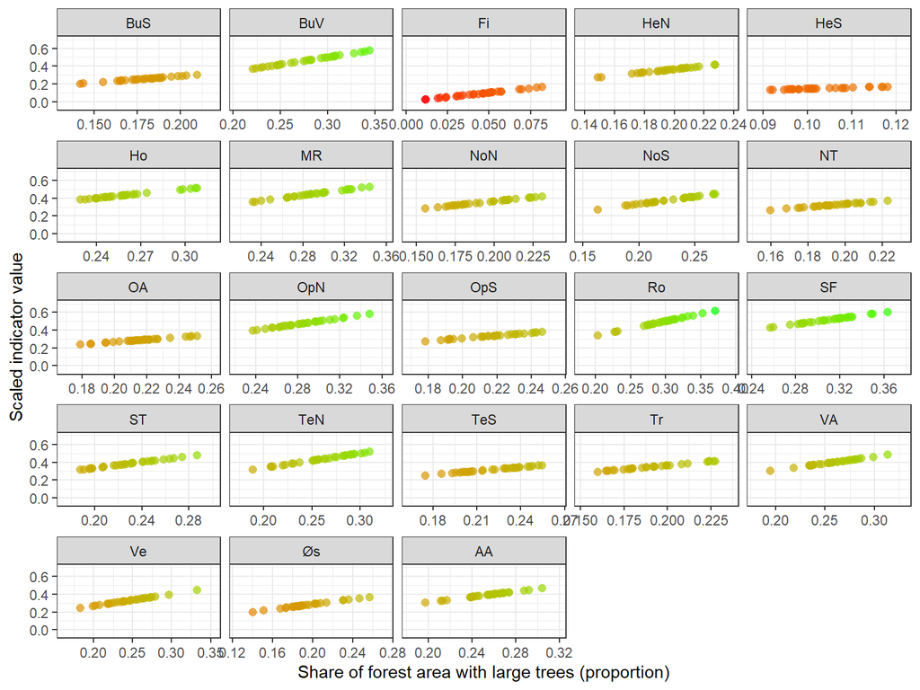

Figure 1: Linear normalisation of the share of forest area with large trees (proportion) to indicator values (0–1), using X0 = 0% and county/sub-county-specific X100. One panel per county or sub-county accounting unit; points are sampled bootstrap draws pooled across reporting periods.

```r
norm_plot_data <- county_draws_scaled |>
  dplyr::group_by(county_part) |>
  dplyr::group_modify(~{
    n_sample <- min(30L, nrow(.x))
    dplyr::slice_sample(.x, n = n_sample, replace = FALSE)
  }) |>
  dplyr::ungroup()

dlta_norm_plot <- ec_norm_plot(
  norm_plot_data$non_scaled_value,
  norm_plot_data$scaled_value
) +
  ggplot2::facet_wrap(~norm_plot_data$county_part, scales = "free_x") +
  ggplot2::labs(
    x = "Share of forest area with large trees (proportion)",
    y = "Scaled indicator value"
  ) +
  ggplot2::theme_bw(base_size = 11)
dlta_norm_plot$layers[[1]]$aes_params$size <- 2.5

suppressMessages(
  ggsave(
    filename = here::here("img/dlta_norm_plot.png"),
    plot = dlta_norm_plot,
    scale = 1.5
  )
)

dlta_norm_plot
```

The scaled draws are then passed to `ecTools::ec_upscale()`, which propagates uncertainty through the spatial hierarchy. For each of 1000 Monte Carlo iterations, one draw is sampled per county and the area-weighted mean gives one regional value; a second `ec_upscale()` call repeats this from regions to national level.

**ec_upscale: county to region**

```r
dlta_mc_rds_regional <- here::here("data/dlta_mc_regional.rds")

dlta_mc_regional <- ecTools::ec_upscale(
  data        = county_draws_scaled,
  variable    = scaled_value,
  weight      = total_area,
  start_units = fylke_name,
  end_units   = region_code,
  year        = period,
  end_units_name = "region_code",
  n = 1000
)
saveRDS(dlta_mc_regional, dlta_mc_rds_regional)
```

**ec_upscale: region to national**

```r
region_area_weights <- county_draws_scaled |>
  dplyr::distinct(period, fylke_name, total_area, region_code) |>
  dplyr::group_by(period, region_code) |>
  dplyr::summarise(region_area = sum(total_area), .groups = "drop")

dlta_mc_regional_for_national <- dlta_mc_regional |>
  dplyr::left_join(region_area_weights, by = c("period", "region_code")) |>
  dplyr::mutate(nation = "National")

dlta_mc_rds_national <- here::here("data/dlta_mc_national.rds")

dlta_mc_national <- ecTools::ec_upscale(
  data        = dlta_mc_regional_for_national,
  variable    = sampled_mean,
  weight      = region_area,
  start_units = region_code,
  end_units   = nation,
  year        = period,
  end_units_name = "nation",
  n = 1000
)
saveRDS(dlta_mc_national, dlta_mc_rds_national)
```

**Combine regional and national MC draws; build summary tables**

```r
dlta_mc_combined <- dplyr::bind_rows(
  dlta_mc_regional |> dplyr::select(period, region = region_code, sampled_mean),
  dlta_mc_national |> dplyr::select(period, region = nation, sampled_mean)
)

county_scaled_all_periods <- dlta_results_county_all_periods |>
  dplyr::inner_join(county_reference, by = "county_part") |>
  dplyr::mutate(
    scaled_value = ec_normalise(indicator_value, x0 = x0, x100 = x100, fun = "linear")
  )

region_scaled_agg_all_periods <- dlta_mc_regional |>
  dplyr::group_by(period, region_code) |>
  dplyr::summarise(scaled_value = median(sampled_mean), .groups = "drop") |>
  dplyr::mutate(region_name = assign_region_name(region_code))

national_scaled_agg_all_periods <- dlta_mc_national |>
  dplyr::group_by(period) |>
  dplyr::summarise(scaled_value = median(sampled_mean), .groups = "drop") |>
  dplyr::mutate(region = "National")

region_scaled_agg_with_uncertainty <- dlta_mc_regional |>
  dplyr::group_by(period, region_code) |>
  dplyr::summarise(
    median = median(sampled_mean),
    p_025  = as.numeric(quantile(sampled_mean, 0.025)),
    p_25   = as.numeric(quantile(sampled_mean, 0.25)),
    p_75   = as.numeric(quantile(sampled_mean, 0.75)),
    p_975  = as.numeric(quantile(sampled_mean, 0.975)),
    .groups = "drop"
  ) |>
  dplyr::mutate(region_name = assign_region_name(region_code)) |>
  dplyr::left_join(
    dlta_results_region_all_periods |> dplyr::select(period, region_code, total_area, n_plots),
    by = c("period", "region_code")
  )

national_scaled_agg_with_uncertainty <- dlta_mc_national |>
  dplyr::group_by(period) |>
  dplyr::summarise(
    median = median(sampled_mean),
    p_025  = as.numeric(quantile(sampled_mean, 0.025)),
    p_25   = as.numeric(quantile(sampled_mean, 0.25)),
    p_75   = as.numeric(quantile(sampled_mean, 0.75)),
    p_975  = as.numeric(quantile(sampled_mean, 0.975)),
    .groups = "drop"
  ) |>
  dplyr::mutate(region = "National") |>
  dplyr::left_join(
    dlta_results_national_all_periods |> dplyr::select(period, total_area, n_plots),
    by = "period"
  )

truncation_summary <- dplyr::bind_rows(
  dlta_results_county_all_periods |>
    dplyr::inner_join(county_reference, by = "county_part") |>
    dplyr::mutate(
      level = "County",
      exceeds_threshold = indicator_value > x100,
      original_value_pct = round(indicator_value * 100, 2),
      reference_value_pct = x100_pct,
      region_code = NA_character_,
      region_name = NA_character_
    ) |>
    dplyr::select(
      period, level, region_code, region_name, fylke_name,
      reference_value_pct, exceeds_threshold, original_value_pct
    ),
  region_scaled_agg_all_periods |>
    dplyr::left_join(
      dlta_results_region_all_periods |> dplyr::select(period, region_code, indicator_value),
      by = c("period", "region_code")
    ) |>
    dplyr::mutate(
      level = "Region",
      exceeds_threshold = scaled_value >= 1,
      original_value_pct = round(indicator_value * 100, 2),
      reference_value_pct = NA_real_,
      fylke_name = NA_character_
    ) |>
    dplyr::select(
      period, level, region_code, region_name, fylke_name,
      reference_value_pct, exceeds_threshold, original_value_pct
    ),
  national_scaled_agg_all_periods |>
    dplyr::left_join(
      dlta_results_national_all_periods |> dplyr::select(period, indicator_value),
      by = "period"
    ) |>
    dplyr::mutate(
      level = "National",
      exceeds_threshold = scaled_value >= 1,
      original_value_pct = round(indicator_value * 100, 2),
      reference_value_pct = NA_real_,
      region_code = NA_character_,
      region_name = "National",
      fylke_name = NA_character_
    ) |>
    dplyr::select(
      period, level, region_code, region_name, fylke_name,
      reference_value_pct, exceeds_threshold, original_value_pct
    )
)

truncation_counts <- truncation_summary |>
  dplyr::group_by(period, level) |>
  dplyr::summarise(
    n_total = dplyr::n(),
    n_exceeding_reference = sum(exceeds_threshold, na.rm = TRUE),
    pct_exceeding_reference = round(100 * n_exceeding_reference / n_total, 1),
    .groups = "drop"
  )

truncated_values <- truncation_summary |>
  dplyr::filter(exceeds_threshold) |>
  dplyr::arrange(period, level, dplyr::desc(original_value_pct))
```

At county or sub-county level, truncation is evaluated by comparing the non-scaled point estimate to the matching *X<sub>100</sub>*. At regional and national level, the tables report cases where the `ec_upscale()` median equals 1. The following tables summarise how often truncation occurred in each period and list the affected units.

| Period | Level | Total | Exceeding reference | % Exceeding reference |
| --- | --- | --- | --- | --- |
| 2010-2014 | County | 23 | 0 | 0.0 |
| 2010-2014 | National | 1 | 0 | 0.0 |
| 2010-2014 | Region | 5 | 0 | 0.0 |
| 2015-2019 | County | 23 | 0 | 0.0 |
| 2015-2019 | National | 1 | 0 | 0.0 |
| 2015-2019 | Region | 5 | 0 | 0.0 |
| 2020-2024 | County | 23 | 0 | 0.0 |
| 2020-2024 | National | 1 | 0 | 0.0 |
| 2020-2024 | Region | 5 | 0 | 0.0 |

```
No values exceeded the county/sub-county X100 reference and required truncation.
```

The time series below (Figure 2) summarises regional and national values.

**Time series of indicator values by region and period**

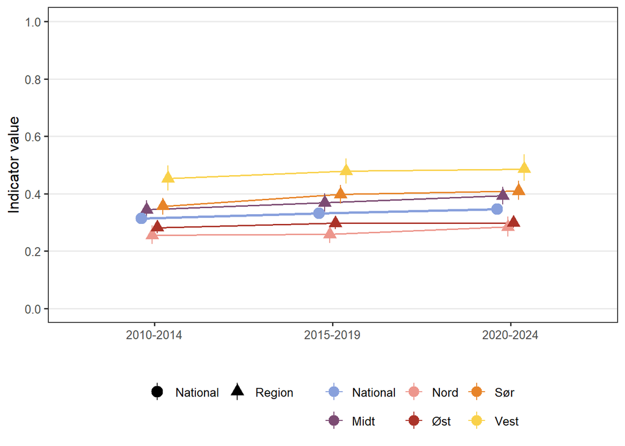

Figure 2: Indicator values for density of large trees by region and reporting period. Points show the MC median; error bars are 95% credible intervals from the Monte Carlo propagation. National values use filled circles and a thicker line.

```r
dlta_region_labels <- c(
  "1" = "Øst", "2" = "Sør", "3" = "Vest",
  "4" = "Midt", "5" = "Nord", "National" = "National"
)
dlta_region_levels <- c("National", "Midt", "Nord", "Øst", "Sør", "Vest")
dlta_region_cols <- setNames(
  MetBrewer::met.brewer("Archambault", n = length(dlta_region_levels)),
  dlta_region_levels
)

dlta_plot_data <- dlta_mc_combined |>
  dplyr::mutate(
    region_name = dplyr::recode(region, !!!dlta_region_labels),
    series_type = dplyr::if_else(region == "National", "National", "Region")
  ) |>
  dplyr::group_by(period, region_name, series_type) |>
  dplyr::summarise(
    median = median(sampled_mean),
    p_025  = as.numeric(quantile(sampled_mean, 0.025)),
    p_975  = as.numeric(quantile(sampled_mean, 0.975)),
    .groups = "drop"
  ) |>
  dplyr::mutate(region_name = factor(region_name, levels = dlta_region_levels))

ggplot2::ggplot(
  dlta_plot_data,
  ggplot2::aes(x = period, y = median, colour = region_name, group = region_name)
) +
  ggplot2::geom_line(
    ggplot2::aes(linewidth = series_type),
    position = ggplot2::position_dodge(width = 0.18)
  ) +
  ggplot2::geom_pointrange(
    ggplot2::aes(ymin = p_025, ymax = p_975, shape = series_type),
    size = 0.8, linewidth = 0.45,
    position = ggplot2::position_dodge(width = 0.18)
  ) +
  ggplot2::scale_colour_manual(values = dlta_region_cols, name = NULL) +
  ggplot2::scale_shape_manual(values = c(National = 19, Region = 17), name = NULL) +
  ggplot2::scale_linewidth_manual(values = c(National = 1, Region = 0.55), guide = "none") +
  ggplot2::scale_y_continuous(limits = c(0, 1), breaks = seq(0, 1, 0.2)) +
  ggplot2::theme_bw(base_size = 12) +
  ggplot2::theme(
    legend.position    = "bottom",
    legend.box         = "horizontal",
    panel.grid.minor   = ggplot2::element_blank(),
    panel.grid.major.x = ggplot2::element_blank()
  ) +
  ggplot2::guides(
    colour = ggplot2::guide_legend(
      nrow = 2,
      override.aes = list(size = 0.7, linewidth = 0.45)
    ),
    shape  = ggplot2::guide_legend(override.aes = list(size = 0.8, linewidth = 0.45))
  ) +
  ggplot2::labs(y = "Indicator value", x = "")
```

## 10. Results

The following tables present scaled indicator results at county or sub-county, regional, and national scales for each reporting period. Tables report the median as the indicator value, with an approximate 95% interval (2.5% and 97.5% quantiles) and an approximate interquartile range (25% and 75% quantiles). All scaled values are on a 0–1 scale, where 0 corresponds to *X<sub>0</sub>* (0% of forest area with large trees) and 1 corresponds to the county or sub-county *X<sub>100</sub>*.

### 10.1 County-level results (scaled with uncertainty)

Use the search box and page controls in Table 5 to browse county rows across all reporting periods.

Table 5: County or sub-county indicator values for density of large trees by reporting period. Values are scaled to 0–1 using X0 and county/sub-county-specific X100 via ec_normalise(). Uncertainty is derived from 1000 bootstrap draws scaled with the same function. The median is reported as the indicator value, with approximate 95% and interquartile intervals from the scaled draw distribution.

| ECT | Indicator | ID | Accounting area | Region | Sub-county | Ecosystem | Reporting period | Indicator value | 95% CI | 50% CI | Number of plots |
| --- | --- | --- | --- | --- | --- | --- | --- | --- | --- | --- | --- |
| B2 | Density of large trees | NO_DLTA_001 | Oslo og Akershus | Øst | OA | Boreal/montane forests | 2010-2014 | 0.28 | 0.23 - 0.33 | 0.26 - 0.3 | 425 |
| B2 | Density of large trees | NO_DLTA_001 | Vestfold | Øst | Ve | Boreal/montane forests | 2010-2014 | 0.28 | 0.2 - 0.36 | 0.25 - 0.31 | 171 |
| B2 | Density of large trees | NO_DLTA_001 | Østfold | Øst | Øs | Boreal/montane forests | 2010-2014 | 0.29 | 0.23 - 0.35 | 0.27 - 0.31 | 327 |
| B2 | Density of large trees | NO_DLTA_001 | Hordaland | Vest | Ho | Boreal/montane forests | 2010-2014 | 0.43 | 0.37 - 0.5 | 0.41 - 0.46 | 507 |
| B2 | Density of large trees | NO_DLTA_001 | Rogaland | Vest | Ro | Boreal/montane forests | 2010-2014 | 0.4 | 0.31 - 0.5 | 0.37 - 0.44 | 258 |
| B2 | Density of large trees | NO_DLTA_001 | Sogn og Fjordane | Vest | SF | Boreal/montane forests | 2010-2014 | 0.5 | 0.43 - 0.58 | 0.48 - 0.53 | 478 |
| B2 | Density of large trees | NO_DLTA_001 | Møre og Romsdal | Midt | MR | Boreal/montane forests | 2010-2014 | 0.4 | 0.33 - 0.46 | 0.37 - 0.42 | 499 |
| B2 | Density of large trees | NO_DLTA_001 | Finnmark | Nord | Fi | Boreal/montane forests | 2010-2014 | 0.08 | 0.02 - 0.16 | 0.06 - 0.1 | 177 |
| B2 | Density of large trees | NO_DLTA_001 | Troms | Nord | Tr | Boreal/montane forests | 2010-2014 | 0.35 | 0.3 - 0.4 | 0.33 - 0.36 | 797 |
| B2 | Density of large trees | NO_DLTA_001 | Aust-Agder | NA | AA | Boreal/montane forests | 2010-2014 | 0.37 | 0.3 - 0.42 | 0.35 - 0.39 | 552 |

[output cut: 59 more lines]

### 10.2 Regional results (scaled with uncertainty)

Table 6: Regional indicator values for density of large trees by reporting period. Scaled values and uncertainty are derived from Monte Carlo propagation (1000 draws per region per period). The median is reported as the indicator value, with approximate 95% and interquartile intervals from the MC distribution.

| ECT | Indicator | ID | Accounting area | Ecosystem | Reporting period | Indicator value | 95% CI | 50% CI | Number of plots |
| --- | --- | --- | --- | --- | --- | --- | --- | --- | --- |
| B2 | Density of large trees | NO_DLTA_001 | Øst | Boreal/montane forests | 2010-2014 | 0.28 | 0.26 - 0.3 | 0.28 - 0.29 | 4,769 |
| B2 | Density of large trees | NO_DLTA_001 | Sør | Boreal/montane forests | 2010-2014 | 0.36 | 0.33 - 0.38 | 0.35 - 0.37 | 1,899 |
| B2 | Density of large trees | NO_DLTA_001 | Vest | Boreal/montane forests | 2010-2014 | 0.45 | 0.41 - 0.5 | 0.44 - 0.47 | 1,243 |
| B2 | Density of large trees | NO_DLTA_001 | Midt | Boreal/montane forests | 2010-2014 | 0.34 | 0.32 - 0.38 | 0.33 - 0.36 | 2,384 |
| B2 | Density of large trees | NO_DLTA_001 | Nord | Boreal/montane forests | 2010-2014 | 0.25 | 0.22 - 0.29 | 0.24 - 0.27 | 2,172 |
| B2 | Density of large trees | NO_DLTA_001 | Øst | Boreal/montane forests | 2015-2019 | 0.30 | 0.28 - 0.31 | 0.29 - 0.3 | 4,764 |
| B2 | Density of large trees | NO_DLTA_001 | Sør | Boreal/montane forests | 2015-2019 | 0.40 | 0.37 - 0.43 | 0.39 - 0.41 | 1,907 |
| B2 | Density of large trees | NO_DLTA_001 | Vest | Boreal/montane forests | 2015-2019 | 0.48 | 0.43 - 0.52 | 0.46 - 0.49 | 1,254 |
| B2 | Density of large trees | NO_DLTA_001 | Midt | Boreal/montane forests | 2015-2019 | 0.37 | 0.34 - 0.4 | 0.36 - 0.38 | 2,390 |
| B2 | Density of large trees | NO_DLTA_001 | Nord | Boreal/montane forests | 2015-2019 | 0.26 | 0.23 - 0.29 | 0.25 - 0.27 | 2,242 |
| B2 | Density of large trees | NO_DLTA_001 | Øst | Boreal/montane forests | 2020-2024 | 0.30 | 0.28 - 0.32 | 0.29 - 0.3 | 4,795 |
| B2 | Density of large trees | NO_DLTA_001 | Sør | Boreal/montane forests | 2020-2024 | 0.41 | 0.38 - 0.45 | 0.4 - 0.42 | 1,908 |
| B2 | Density of large trees | NO_DLTA_001 | Vest | Boreal/montane forests | 2020-2024 | 0.49 | 0.45 - 0.54 | 0.47 - 0.5 | 1,272 |
| B2 | Density of large trees | NO_DLTA_001 | Midt | Boreal/montane forests | 2020-2024 | 0.39 | 0.36 - 0.42 | 0.38 - 0.4 | 2,391 |
| B2 | Density of large trees | NO_DLTA_001 | Nord | Boreal/montane forests | 2020-2024 | 0.28 | 0.25 - 0.32 | 0.27 - 0.3 | 2,241 |

### 10.3 National results (scaled with uncertainty)

Table 7: National indicator values for density of large trees by reporting period. Scaled values and uncertainty are derived from Monte Carlo propagation (1000 draws). The median is reported as the indicator value, with approximate 95% and interquartile intervals from the MC distribution.

| ECT | Indicator | ID | Accounting area | Ecosystem | Reporting period | Indicator value | 95% CI | 50% CI | Number of plots |
| --- | --- | --- | --- | --- | --- | --- | --- | --- | --- |
| B2 | Density of large trees | NO_DLTA_001 | National | Boreal/montane forests | 2010-2014 | 0.31 | 0.3 - 0.33 | 0.31 - 0.32 | 12,467 |
| B2 | Density of large trees | NO_DLTA_001 | National | Boreal/montane forests | 2015-2019 | 0.33 | 0.32 - 0.34 | 0.33 - 0.34 | 12,557 |
| B2 | Density of large trees | NO_DLTA_001 | National | Boreal/montane forests | 2020-2024 | 0.35 | 0.33 - 0.36 | 0.34 - 0.35 | 12,607 |

## 11. Export file

Regional and national Monte Carlo draws are exported in one table (`dlta_mc_combined`: `period`, `region`, `sampled_mean`; `region` contains the five NI region codes and `"National"`).

**Export regional and national MC-propagated indicator draws**

```r
write.csv(
  dlta_mc_combined,
  here::here("data/results_NO_DLTA_001.csv"),
  row.names = FALSE
)
```

## 12. Author contributions

**CRediT statement**

- Conceptualization: [UJA, KOS]
- Methodology: [UJA, KOS, AHH]
- Data curation: [OS]
- Formal analysis: [AHH]
- Validation: [AHH, OS, KOS]
- Visualization: [AHH]
- Writing – original draft: [AHH, UJA]
- Writing – review & editing: [All]

**MeRIT attribution**

This part supplements the CRediT statement with more granularity for method section.

**Session Info**

This workflow uses `renv`. Run `renv::restore()` to recreate the working environment.